# MIE237

2016-02-02

## regression

## More on \(\hat\beta_1\)

Estimation based on the model \(y_i = \beta_0 + \beta_1 x_i + \varepsilon_i\).

Other model assumptions: \(\varepsilon_i\) are i.i.d. \(N(0, \sigma^2)\). So the \(y_i\) are also normal, with mean \(\beta_0 + \beta_1x_i\) and variance \(\sigma^2\).

Important to remember that \(\hat\beta_1\) is a *random variable* with a distribution, mean, and variance of its own. (\(\beta_0\) too.)

In fact \({E\left( \hat\beta_1 \right)} = \beta_1\) and its variance is \(\frac{\sigma^2}{S_{xx}}\).

**Notation:** textbook uses \(b_1\) where I use \(\hat\beta_1\) etc.

## Distribution of \(\hat\beta_1\)

\[\hat\beta_1 = \frac{\sum_{i=1}^n(y_i-\overline y) (x_i-\overline{x})}{S_{xx}}\]

(Sometimes I'll use \(y_i\) as a random variable rather than data.)

So: \(\displaystyle \frac{\hat\beta_1 - \beta_1}{\sigma/\sqrt{S_{xx}}} \sim N(0,1)\)

Goals: make CI for \(\beta_1\) and test \(H_0: \beta_1=0\) versus the alternative.

But we don't know \(\sigma\).

## Some simulated data

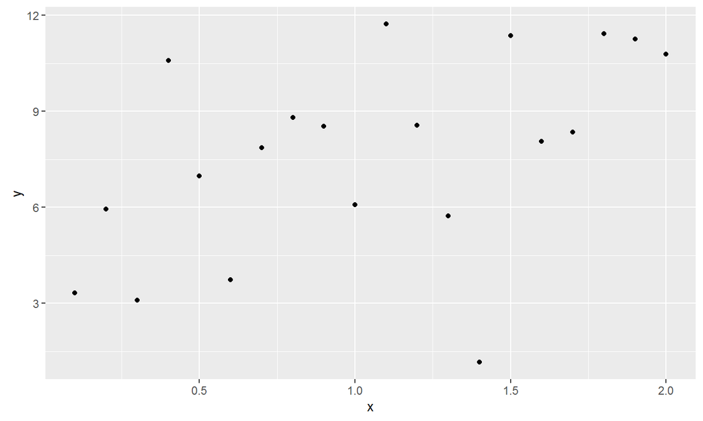

## estimating \(\sigma\)

We begin by considering the variation in the outputs \({y_1,\ldots,y_n}\) when we don't try to use the \(x_i\) in any model at all:

\[\sum_{i=1}^n \left(y_i - {\overline{y}}\right)^2\]

This is the just the numerator of the sample variance of the \({y_1,\ldots,y_n}\) and is what we'd use for the basic \(y_i = \mu + {\varepsilon}\) model.

We'll call this the *Total Sum of Squares* or SST. We will decompose this into two parts: a *model* (or *regression*) part and a pure *error* (or *residual*) part.

## TSS on the data

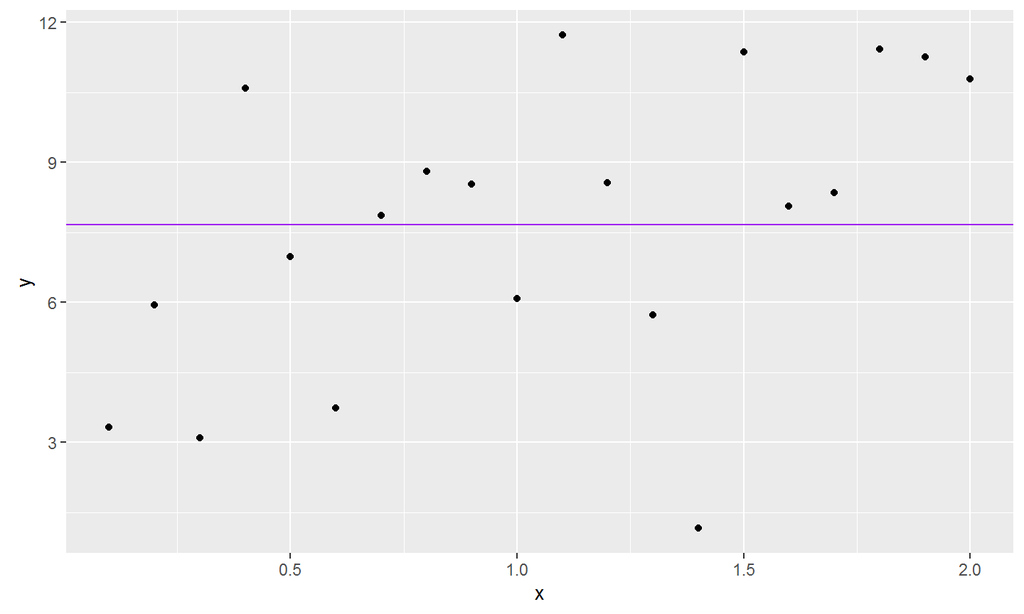

## Fitted values and residuals

To do the decomposition we need to define a few things.

The *fitted values* are the points on the fitted regression line evaluated at the \(x_i\) in the data. Notation:\[ \hat y_i = \hat\beta_0 + \hat\beta_1 x_i \]

The *residuals* are the differences between the fitted values and the observed responses \(y_i\):\[\hat{\varepsilon}_i = y_i - \hat y_i\]

## Fitted values and residuals on the data

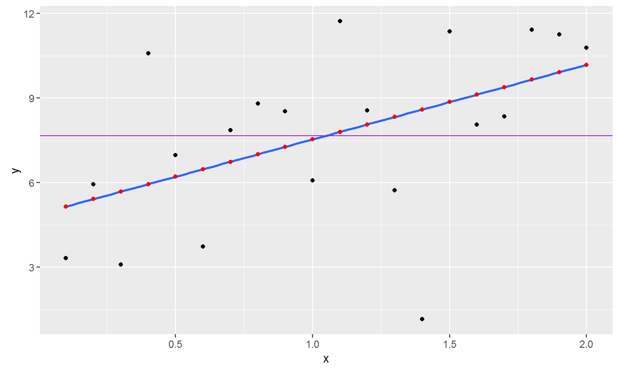

## The sum of squares decomposition

\[\begin{align} SST &=\sum_{i=1}^n\left(y_i - \overline y\right)^2 =\sum_{i=1}^n\left(y_i - \hat y_i + \hat y_i - \overline y\right)^2\\ &= \sum_{i=1}^n\left(y_i - \hat y_i\right)^2 + \sum_{i=1}^n\left(\hat y_i - \overline y\right)^2 + 2\text{(cross product)}\\ &= \sum_{i=1}^n\left(\hat y_i - \overline y\right)^2 + \sum_{i=1}^n\left(y_i - \hat y_i\right)^2 \end{align}\]

We call the term on the left the *regression sum of squares* or \(SSR\) and the last term the *error sum of squares* (or *residual sum of squares*) or \(SSE\) and we get:\[SST = SSR + SSE\]

## Distributions of the sums of squares

\[\sum_{i=1}^n\left(y_i - \overline y\right)^2 = \sum_{i=1}^n\left(\hat y_i - \overline y\right)^2 + \sum_{i=1}^n\left(y_i - \hat y_i\right)^2\]

They are all sums of squares of normal distributions.

So they have \(\chi^2\) distributions.

The degrees of freedom are \(n-1\), \(1\), and \(n-2\), respectively. (They add up!)

And we have our estimator for \(\sigma^2\):\[\frac{SSE}{n-2}\]which we also call the mean squared error or \(MSE\).

## Inference for the slope parameter

Main hypothesis test: \(H_0:\beta_1=0\) versus \(H_1:\beta_1\ne 0\). We might want to make a CI as well.

Key fact:\[T=\frac{\hat\beta_1 - \beta_1}{\sqrt{MSE}/\sqrt{S_{xx}}}\sim t_{n-2}\]

## In R - the SS decomposition

```r
anova(regr_lm)
```

```
## Analysis of Variance Table
##
## Response: y
##           Df  Sum Sq Mean Sq F value  Pr(>F)
## x          1  46.611  46.611       6 0.02477 *
## Residuals 18 139.832   7.768
## ---
## Signif. codes:  0 '***' 0.001 '**' 0.01 '*' 0.05 '.' 0.1 ' ' 1
```

## In R - summary results

```
##
## Call:
## lm(formula = y ~ x, data = regr_data)
##
## Residuals:
##     Min      1Q  Median      3Q     Max
## -7.4423 -1.5505  0.5624  1.4499  4.6351
##
## Coefficients:
##             Estimate Std. Error t value Pr(>|t|)
## (Intercept)    4.892      1.295   3.778  0.00138 **
## x              2.647      1.081   2.449  0.02477 *
## ---
## Signif. codes:  0 '***' 0.001 '**' 0.01 '*' 0.05 '.' 0.1 ' ' 1
##
## Residual standard error: 2.787 on 18 degrees of freedom
## Multiple R-squared:   0.25,  Adjusted R-squared:  0.2083
## F-statistic:     6 on 1 and 18 DF,  p-value: 0.02477
```